# 05 — VaR & Expected Shortfall

This notebook extends the volatility modeling performed in *04 — EGARCH & Volatility Backtesting* to quantify, interpret, and validate extreme financial risk for the IBEX 35 (Spain) and S&P 500 (US) indices. While the EGARCH captured how volatility evolves over time, VaR and ES translate that volatility into **potential daily losses**, answering the practical question: *“How much could we lose, and how often?”*

The **VaR** provides a probabilistic threshold of losses under normal market conditions, whereas the **Expected Shortfall (ES)** measures the average loss once the VaR threshold is breached, offering a deeper look into the tail of the distribution — and serving as the core risk metric under Basel III standards.

To validate these measures empirically, the notebook applies **Kupiec (coverage)** and **Christoffersen (independence)** backtesting tests,  
evaluating whether the frequency and clustering of losses align with theoretical expectations. Together, these analyses assess whether the EGARCH-based volatility models can accurately forecast tail risk and whether the degree of risk conservatism differs between the Spanish and U.S. markets.

### Objectives

- Compute **time-varying Value at Risk (VaR)** at 95% and 99% confidence levels.
- Compute **Expected Shortfall (ES)** at the 99% level from the EGARCH conditional variance.
- Perform **Kupiec (coverage)** and **Christoffersen (independence)** backtesting tests.
- Compare the adequacy of the risk measures for both indices.
- Interpret how volatility persistence translates into tail-risk behaviour.

| File | Description |
| --- | --- |
| `/data/models/egarch_ibex.pkl` | Fitted EGARCH(1,1)-t model for IBEX 35. |
| `/data/models/egarch_spx.pkl` | Fitted EGARCH(1,1)-t model for S&P 500. |
| `/data/features/returns.csv` | Daily log-returns of both indices. |

### Outputs

[output not shown]

| `/figures/var_es_spx.png` | Daily returns vs VaR95 / VaR99 / ES99 (S&P 500).

### Tests to be Performed

| Test | Purpose |
| --- | --- |
| **Kupiec Test (Unconditional Coverage)** | Verify if the observed violation rate ≈ nominal α. |
| **Christoffersen Test (Independence)** | Test whether VaR exceedances occur independently over time. |

### Notebook Structure

1. **Setup & Imports** — load models and returns.
2. **Compute Dynamic VaR** — derive daily VaR95 and VaR99 from EGARCH conditional variance.
3. **Compute Expected Shortfall (ES)** — calculate ES99 based on t-distribution.
4. **Backtesting** — perform Kupiec and Christoffersen tests on both indices.
5. **Visualization** — plot VaR/ES overlays on daily returns.
6. **Analytical Summary** — interpret tail-risk behaviour and model adequacy.
7. **Power BI Export Summary** — generate a consolidated dataset (var_es_results.csv)

```python
# 1. SETUP & IMPORTS

# Core libraries
import sys
import warnings
from pathlib import Path
import pandas as pd
import numpy as np
import matplotlib.pyplot as plt
import joblib
from scipy.stats import t

# Configure project paths
ROOT = Path.cwd().parent
SRC_DIR = ROOT / "src"
DATA_DIR = ROOT / "data"
MODEL_DIR = DATA_DIR / "models"
FEATURES_DIR = DATA_DIR / "features"
FIG_DIR = ROOT / "figures" / "05.VaR_ES"

# Ensure project structure is available
sys.path.append(str(SRC_DIR))

# Import project modules
from volatility import backtest_var  # from previous notebook (EGARCH functions)

# Ensure required directories exist
FIG_DIR.mkdir(parents=True, exist_ok=True)
MODEL_DIR.mkdir(parents=True, exist_ok=True)

# Load EGARCH models (from previous notebook)
model_ibex = joblib.load(MODEL_DIR / "egarch_ibex.pkl")
model_spx  = joblib.load(MODEL_DIR / "egarch_spx.pkl")

# Load daily return series
returns = pd.read_csv(FEATURES_DIR / "returns.csv", index_col=0, parse_dates=True)
returns.columns = ["IBEX", "SPX"]
returns = returns.asfreq("B")

# Display confirmation and structure summary
print("Data and EGARCH models loaded successfully.\n")
print(f" Models directory:  {MODEL_DIR}")
print(f" Figures directory: {FIG_DIR}")
print(f"IBEX model: {type(model_ibex).__name__}")
print(f" SPX  model: {type(model_spx).__name__}")
print(f"\nReturns loaded → {returns.shape[0]} observations, {returns.shape[1]} columns.\n")

# Visualisation style
plt.style.use("seaborn-v0_8-whitegrid")

# Suppress non-critical
warnings.filterwarnings("ignore", message="No frequency information")
warnings.filterwarnings("ignore", category=UserWarning)
warnings.filterwarnings("ignore", category=RuntimeWarning)
```

```
Data and EGARCH models loaded successfully.

 Models directory:  /home/apalo/projects/ibex-sp500-forecasting/data/models
 Figures directory: /home/apalo/projects/ibex-sp500-forecasting/figures/05.VaR_ES
IBEX model: ARCHModelResult
 SPX  model: ARCHModelResult

Returns loaded → 6760 observations, 2 columns.
```

### Value at Risk (VaR) — Definition

To quantify extreme downside risk, we compute the (\alpha)-level **Value at Risk (VaR)**, defined as the loss threshold exceeded with probability (\alpha):

$$ \text{VaR}_{\alpha} = \inf \{ x : F(x) \ge \alpha \} $$

When returns follow a parametric distribution with conditional mean (\mu_t) and conditional volatility (\sigma_t), the dynamic VaR can be expressed as:

$$ \text{VaR}_{\alpha,t} = \mu_t + \sigma_t \, z_{\alpha} $$

Dynamic VaR adapts period by period as volatility changes, making it suitable for risk monitoring under time-varying uncertainty.

```python
# 2. COMPUTE DYNAMIC VALUE-AT-RISK (VaR 95% & 99%)

from volatility import compute_var
from scipy.stats import t

# Confidence levels
alphas = [0.05, 0.01]

# Container for VaR results
var_results = {}

for label, model in {"IBEX": model_ibex, "SPX": model_spx}.items():
    print(f"\nComputing dynamic VaR for {label}...")

    # Extract conditional volatility and degrees of freedom
    sigma = model.conditional_volatility
    dof = model.params["nu"]  # Student-t DoF

    # Dynamic VaR estimation (loss thresholds) ---
    var95 = compute_var(sigma, dist=t(dof), alpha=0.05)
    var99 = compute_var(sigma, dist=t(dof), alpha=0.01)

    # Store only VaR for now
    var_results[label] = {"VaR95": var95, "VaR99": var99}

    # Quick preview
    df_preview = pd.concat([var95, var99], axis=1).head()
    df_preview.columns = ["VaR95", "VaR99"]
    print(f"\nPreview for {label}:\n")
    display(df_preview)

print("\nDynamic VaR computed successfully for both indices.")
```

```
Computing dynamic VaR for IBEX...

Preview for IBEX:
```

| Date | VaR95 | VaR99 |
| --- | --- | --- |
| 2000-01-04 | -2.511836 | -3.942064 |
| 2000-01-05 | -2.660958 | -4.176096 |
| 2000-01-07 | -2.757962 | -4.328333 |
| 2000-01-10 | -2.774389 | -4.354113 |
| 2000-01-11 | -2.694711 | -4.229067 |

```
Computing dynamic VaR for SPX...

Preview for SPX:
```

| Date | VaR95 | VaR99 |
| --- | --- | --- |
| 2000-01-04 | -2.501591 | -4.037450 |
| 2000-01-05 | -2.755553 | -4.447332 |
| 2000-01-07 | -2.624292 | -4.235484 |
| 2000-01-10 | -2.728115 | -4.403049 |
| 2000-01-11 | -2.674121 | -4.315904 |

```
Dynamic VaR computed successfully for both indices.
```

**Interpretation:**

- A more negative VaR means higher potential losses.
- VaR 99% is always more extreme than VaR 95%, as it represents rarer tail events.
- The Student-t distribution captures fat tails, meaning larger losses occur more frequently than under a Normal model.
- Dynamic VaR evolves daily with the conditional variance; when volatility clusters rise, VaR deepens accordingly.

**Key insight:**  
Both indices show realistic VaR thresholds (e.g., –2.5 % at 95 % and –4.0 % at 99 %),  
indicating that the EGARCH model successfully links volatility clustering to daily downside risk.  
The S&P 500 tends to have slightly more negative VaR levels, consistent with its heavier tails and higher tail risk.

### 3. Compute Expected Shortfall (ES 99 %)

While VaR indicates the loss threshold not exceeded with probability (99%), it provides no information about the severity of losses beyond that threshold. Expected Shortfall (ES), also called Conditional VaR, solves this by measuring the average loss given that the VaR level has already been breached.

For a Student-t distribution with degrees of freedom:

$$ ES_{\alpha,t} =\mu_t + \sigma_t \, \frac{ f_{t,\nu}(z_{\alpha}) }{ \alpha } \, \frac{ \nu + z_{\alpha}^2 }{ \nu - 1 } $$

```python
# 3. COMPUTE EXPECTED SHORTFALL (ES 99%)

from risk_metrics import compute_es

for label, model in {"IBEX": model_ibex, "SPX": model_spx}.items():
    print(f"\nComputing Expected Shortfall (ES99) for {label}...")

    # Extract volatility and degrees of freedom again
    sigma = model.conditional_volatility
    dof = model.params["nu"]

    # Expected Shortfall
    es99 = compute_es(sigma, dof=dof, alpha=0.01)

    # Add ES to dictionary
    var_results[label]["ES99"] = es99

    # Preview combined results
    df_preview = pd.concat(
        [var_results[label]["VaR95"], var_results[label]["VaR99"], es99],
        axis=1
    ).head()
    df_preview.columns = ["VaR95", "VaR99", "ES99"]
    print(f"\nPreview for {label}:\n")
    display(df_preview)

# Save full results
out_path = MODEL_DIR / "var_es_series.pkl"
joblib.dump(var_results, out_path)
print(f"\nDynamic VaR & ES series saved → {out_path}")
```

```
Computing Expected Shortfall (ES99) for IBEX...

Preview for IBEX:
```

| Date | VaR95 | VaR99 | ES99 |
| --- | --- | --- | --- |
| 2000-01-04 | -2.511836 | -3.942064 | -6.586958 |
| 2000-01-05 | -2.660958 | -4.176096 | -7.392282 |
| 2000-01-07 | -2.757962 | -4.328333 | -7.941066 |
| 2000-01-10 | -2.774389 | -4.354113 | -8.035946 |
| 2000-01-11 | -2.694711 | -4.229067 | -7.581004 |

```
Computing Expected Shortfall (ES99) for SPX...

Preview for SPX:
```

| Date | VaR95 | VaR99 | ES99 |
| --- | --- | --- | --- |
| 2000-01-04 | -2.501591 | -4.037450 | -6.672352 |
| 2000-01-05 | -2.755553 | -4.447332 | -8.095874 |
| 2000-01-07 | -2.624292 | -4.235484 | -7.342951 |
| 2000-01-10 | -2.728115 | -4.403049 | -7.935453 |
| 2000-01-11 | -2.674121 | -4.315904 | -7.624446 |

```
Dynamic VaR & ES series saved → /home/apalo/projects/ibex-sp500-forecasting/data/models/var_es_series.pkl
```

**Interpretation:**

- ES is always more negative than VaR since it averages losses *beyond* the cutoff.
- The gap between VaR 99 and ES 99 quantifies the *severity of tail events* — a large gap indicates fat tails and higher systemic risk.
- ES satisfies sub-additivity and convexity, making it preferred in regulatory frameworks like Basel III.

**Key insight:**  
The obtained ES values (e.g., around –7 % to –8 %) are roughly twice as large as the corresponding VaR 99 %, confirming that the extreme-tail losses are significantly deeper than the VaR cut-off. This result demonstrates that the EGARCH-t framework captures both the volatility clustering and heavy-tailed behaviour typical of real financial returns.

## 4. Backtesting: Brief introduction to Kupiec & Christoffersen Tests

To validate whether our VaR estimates are reliable, we apply two standard backtesting procedures.  
These tests check if the model produces the correct number of VaR violations and whether those violations occur randomly over time rather than in clusters.

### Kupiec Unconditional Coverage Test

Evaluates whether the **observed frequency** of VaR violations matches the expected rate.

$$ LR_{\text{UC}} = -2 \left[ \log\left( (1-\alpha)^{T-n} \alpha^n \right)- \log\left( (1-\hat{p})^{T-n} \hat{p}^n \right) \right] $$

This test answers: **Is the model getting the right number of violations?**

### Christoffersen Independence Test

Checks whether VaR violations are **independent over time**. A good model should not produce clusters of consecutive failures.

Transition probabilities:

$$ \pi_0 = \frac{n_{01}}{n_{00} + n_{01}}, \qquad \pi_1 = \frac{n_{11}}{n_{10} + n_{11}} $$

Independence likelihood-ratio:

$$ LR_{\text{IND}} = -2 (\log L_0 - \log L_1) $$

This test answers: **Do violations occur randomly, rather than in streaks?**

Together, these tests confirm whether the VaR model has correct coverage and proper violation dynamics.

```python
# 4. BACKTESTING — Kupiec (Coverage) & Christoffersen (Independence)

from volatility import backtest_var
from risk_metrics import christoffersen_test

# Load previously computed VaR/ES series
var_results = joblib.load(MODEL_DIR / "var_es_series.pkl")

backtest_summary = []

for label in ["IBEX", "SPX"]:
    print(f"\nBacktesting VaR coverage and independence for {label}...")

    # Scale returns ×100 to match VaR/ES scale
    series = returns[label].dropna() * 100

    var95 = var_results[label]["VaR95"]
    var99 = var_results[label]["VaR99"]

    for alpha, var_series in zip([0.05, 0.01], [var95, var99]):
        series_aligned, var_aligned = series.align(var_series, join="inner")

        exceedances = (series_aligned < var_aligned).astype(int)

        # Kupiec test
        kupiec = backtest_var(series_aligned, var_aligned, alpha=alpha)

        # Christoffersen test
        christ = christoffersen_test(exceedances)

        backtest_summary.append({
            "Index": label,
            "alpha": alpha,
            "violations": kupiec["violations"],
            "violation_ratio": kupiec["violation_ratio"],
            "kupiec_lr": kupiec["kupiec_lr"],
            "kupiec_p": kupiec["p_value"],
            "christoffersen_lr": christ["lr_ind"],
            "christoffersen_p": christ["p_value"]
        })

backtest_df = pd.DataFrame(backtest_summary)
display(backtest_df)

out_csv = MODEL_DIR / "var_es_backtest.csv"
backtest_df.to_csv(out_csv, index=False)
print(f"\nBacktesting summary saved → {out_csv}")
```

```
Backtesting VaR coverage and independence for IBEX...

Backtesting VaR coverage and independence for SPX...
```

|  | Index | alpha | violations | violation_ratio | kupiec_lr | kupiec_p | christoffersen_lr | christoffersen_p |
| --- | --- | --- | --- | --- | --- | --- | --- | --- |
| 0 | IBEX | 0.05 | 337 | 1.05 | NaN | NaN | 21.018677 | 0.000005 |
| 1 | IBEX | 0.01 | 80 | 1.25 | 3.638082 | 0.056472 | 2.707252 | 0.099893 |
| 2 | SPX | 0.05 | 241 | 0.75 | NaN | NaN | 12.672730 | 0.000371 |
| 3 | SPX | 0.01 | 44 | 0.69 | 7.222884 | 0.007198 | 8.729049 | 0.003132 |

```
Backtesting summary saved → /home/apalo/projects/ibex-sp500-forecasting/data/models/var_es_backtest.csv
```

### 4.1 Interpretation of VaR Backtesting Results

The backtesting procedure evaluates whether the **EGARCH(1,1)-t VaR forecasts** accurately capture both the frequency and the temporal distribution of extreme losses for the indices.

#### Kupiec Test (Unconditional Coverage)

The **Kupiec likelihood ratio test** examines whether the proportion of days in which actual losses exceeded the predicted VaR  
matches the theoretical exceedance probability (α).

- **Null hypothesis (H₀):** the model provides correct unconditional coverage (observed vs. expected violations are consistent).
- **High p-value (> 0.05):** correct coverage → the model predicts the right number of exceedances.
- **Low p-value (< 0.05):** incorrect coverage → the model underestimates (too many violations) or overestimates (too few) tail risk.

This test measures how many times the VaR is breached, but not when those breaches occur.

#### Christoffersen Test (Independence)

Even if the total number of exceedances is correct, they must occur independently over time.  
The **Christoffersen test** evaluates the **Markov dependence** between consecutive violations (1 = breach, 0 = no breach):

- **Null hypothesis (H₀):** exceedances are independent over time.
- **High p-value (> 0.05):** no clustering → the model adjusts well to changing volatility.
- **Low p-value (< 0.05):** clustered exceedances → the model reacts with delay to volatility shocks or crisis periods.

This test identifies whether VaR breaches occur randomly or in bursts, indicating the model’s ability to adapt dynamically to stress episodes.

#### Empirical Results and Implications

[output not shown]

#### Implications for Model Adequacy

**Next Step:**  
Visualize the VaR and ES time series alongside actual returns to observe how the model behaves during volatility spikes and crisis episodes.

```
Saving figures to: /home/apalo/projects/ibex-sp500-forecasting/figures/05.VaR_ES

Plotting VaR & ES overlay for IBEX...
Figure saved → /home/apalo/projects/ibex-sp500-forecasting/figures/05.VaR_ES/var_es_ibex.png
```

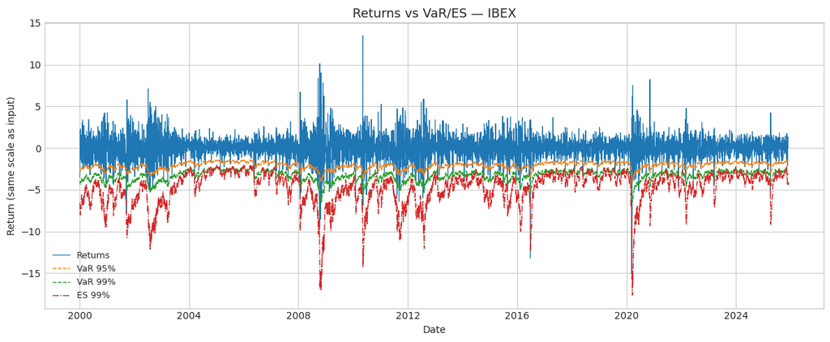

```
Plotting VaR & ES overlay for SPX...
Figure saved → /home/apalo/projects/ibex-sp500-forecasting/figures/05.VaR_ES/var_es_spx.png
```

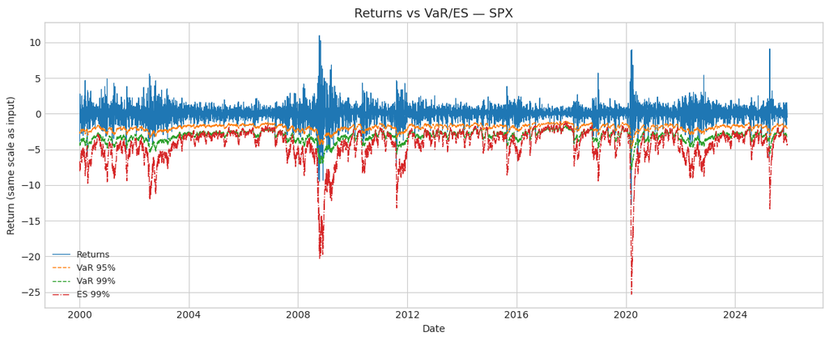

```
All VaR & ES visualizations saved successfully.
```

```python
# 5. VISUALIZATION — VaR & ES Overlays on Returns

from risk_metrics import plot_var_es

# Ensure figure directory exists
FIG_DIR.mkdir(parents=True, exist_ok=True)

print(f"Saving figures to: {FIG_DIR}\n")

# Reload results in case notebook resumed from checkpoint
var_results = joblib.load(MODEL_DIR / "var_es_series.pkl")

for label in ["IBEX", "SPX"]:
    print(f"Plotting VaR & ES overlay for {label}...")

    # Extract aligned data
    series = returns[label].dropna() * 100  # scale to match VaR/ES
    var95 = var_results[label]["VaR95"]
    var99 = var_results[label]["VaR99"]
    es99 = var_results[label]["ES99"]

    # Align indices
    series_aligned, var95_aligned = series.align(var95, join="inner")
    _, var99_aligned = series.align(var99, join="inner")
    _, es99_aligned = series.align(es99, join="inner")

    # Define output path
    fig_path = FIG_DIR / f"var_es_{label.lower()}.png"

    # Plot returns vs VaR & ES
    plot_var_es(
        series_aligned,
        var95_aligned,
        var99_aligned,
        es99_aligned,
        label=label,
        fig_path=fig_path
    )

print("\nAll VaR & ES visualizations saved successfully.")
```

### 5.1 Visualization and Interpretation

The figures generated in this section plot the **daily returns** of the **IBEX 35** and **S&P 500** against their corresponding **dynamic VaR95, VaR99, and ES99** series derived from the EGARCH(1,1)-t models.

#### Visual interpretation:

- During **calm periods**, returns remain within VaR bounds → model stability and accurate calibration.
- During **volatility spikes or crises**, the VaR and ES lines widen (move downward),  
  reflecting the model’s adaptive response to increased conditional variance.
- **ES99** consistently lies below VaR99, capturing the **expected magnitude** of extreme losses beyond the VaR cutoff.

#### Key takeaway:

These overlays confirm that the EGARCH-t framework provides **dynamic, data-driven risk boundaries** that widen during turbulent periods and narrow during calm markets, illustrating its ability to capture **time-varying tail risk** in both European and U.S. markets.

**Next step:**  
The final section (Analytical Summary) will integrate the numerical and visual diagnostics to assess overall model adequacy, backtesting validity, and implications for **risk management and capital allocation**.

# 6. Analytical Summary

This final section consolidates everything accomplished in **Notebook 05 — VaR & Expected Shortfall**, which extended the volatility modeling from *04 — EGARCH & Volatility Backtesting into a practical evaluation of **extreme market risk** for the **IBEX 35** and **S&P 500**.

In essence, this notebook transforms econometric volatility models into **actionable tail-risk tools**,  
directly applicable to **portfolio management, stress testing, and regulatory capital frameworks**.

### Conceptual Purpose

While the previous notebook focused on volatility dynamics, this one **translates them into measurable risk metrics** — turning conditional variance into real-world loss thresholds. Using the EGARCH-t model, we computed **Value at Risk (VaR)** and **Expected Shortfall (ES)**, validated them through the **Kupiec** and **Christoffersen** tests, and visualized their time-varying behaviour.

Together, these elements provide a complete empirical picture of **tail-risk exposure** its **frequency**, **severity**, and **temporal clustering**.

### 6.1 From Volatility to Tail-Risk Measures

- **VaR95 / VaR99** quantify the maximum daily loss not expected to be exceeded with 95 % or 99 % confidence.
- **ES99** captures the *average loss once VaR99 has been breached*, offering a more conservative tail measure.

### 6.2 Empirical Findings

**IBEX 35**

**S&P 500**

### 6.3 Visualization Insights

The VaR/ES overlays illustrate risk dynamics through time:

- **Calm periods:** returns remain above VaR limits → stable calibration.
- **Crisis periods:** VaR and ES expand downward → volatility spikes captured.
- **ES99** stays below VaR99, quantifying the *average magnitude* of losses beyond the tail cutoff.

IBEX shows moderate, short clusters of exceedances;  
S&P 500 shows deeper but rarer ones, consistent with **fat-tailed U.S. market behaviour** (ν ≈ 5).

### 6.4 Limitations and Extensions

- The EGARCH(1,1) model is **univariate**, so it cannot capture **cross-market contagion** or joint volatility shocks.
- Clustering at 95 % suggests the need for **multi-regime or higher-order specifications** (e.g., EGARCH(1,2)).
- Extending to **multivariate or copula-based models** would enable analysis of **co-movements and systemic risk**.
- The current horizon is **one day**; multi-day or portfolio-level risk aggregation remains for future development.

Despite these constraints, the model successfully reproduces the main **short-term, distributional characteristics** of both indices and offers a solid foundation for applied risk forecasting.

### Next Notebook

This notebook concludes the **univariate tail-risk quantification phase** of the project.  
We now possess:

- Validated EGARCH-t volatility structures,
- Consistent VaR / ES forecasts, and
- Diagnostic evidence of how risk evolves across markets and confidence levels.

The next stage — *Notebook 06 — Directional Random Forest Model* —  
introduces **supervised machine learning** to estimate the probability of positive or negative daily returns  
in both indices, leveraging past returns, conditional volatility, and additional derived financial predictors.

## 7. Power BI Export Summary

```python
# STEP 7 — Export DAILY VaR Dataset for Power BI / Final Analysis

import pandas as pd
from pathlib import Path

RESULTS_PATH = Path.cwd().parent / "data" / "results"

daily_frames = []

for label, model in {"IBEX": model_ibex, "SPX": model_spx}.items():

    # Returns aligned with model vol
    rets = returns[label].loc[model.conditional_volatility.index]

    # VaR series
    var95 = var_results[label]["VaR95"]
    var99 = var_results[label]["VaR99"]

    # Daily backtesting indicators
    breach95 = (rets < var95).astype(int)
    breach99 = (rets < var99).astype(int)

    df_daily = pd.DataFrame({
        "Date": var95.index,
        "Index": label,
        "Return": rets,
        "VaR95": var95,
        "VaR99": var99,
        "Breach95": breach95,
        "Breach99": breach99,
    })

    daily_frames.append(df_daily)

# IBEX + SPX concatenados
var_es_results_daily = pd.concat(daily_frames).reset_index(drop=True)

# Export CSV
output_path = RESULTS_PATH / "var_es_results_daily.csv"
var_es_results_daily.to_csv(output_path, index=False)

print(f"Daily VaR dataset exported successfully → {output_path}")

# Preview
var_es_results_daily.head()

# EXPORT TO WINDOWS FOR POWER BI

import sys
from pathlib import Path

ROOT = Path.cwd().parent
sys.path.append(str(ROOT / "src"))

from export import export

try:
    export(var_es_results_daily, "var_es_results_daily")
    print("Daily VaR dataset exported to Windows for Power BI.")
except Exception as e:
    print("Export failed:", e)
```

```
Daily VaR dataset exported successfully → /home/apalo/projects/ibex-sp500-forecasting/data/results/var_es_results_daily.csv
[EXPORT] var_es_results_daily.csv saved to /mnt/c/Users/apalo/Desktop/forescasting_results/var_es_results_daily.csv
Daily VaR dataset exported to Windows for Power BI.
```